# Test

Lee, Yeon-Ju

2021 7 20

#### 11.datasets::cars데이터 셋을 이용하여 속도에 대한 제동거리의 산점도와 적합도(신뢰구간

#### 그래프)를 나타내시오(단, 속도가 5부터 20까지 제동거리 0부터 100까지만 그래프에 나타냄).

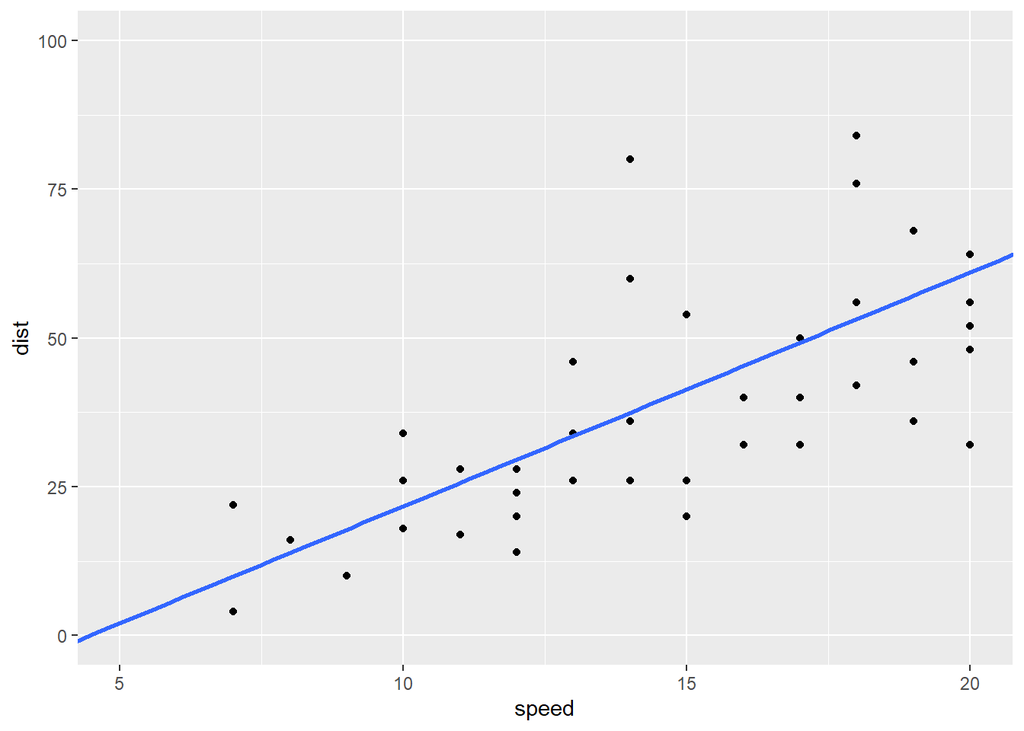

```r
library(ggplot2)
library(car)
ggplot(cars, aes(x=speed, y=dist)) +
  geom_point() +
  geom_smooth(method = 'lm') +
  coord_cartesian(ylim=c(0,100), xlim=c(5,20))
```

#### 12.gapminder::gapminder 데이터 셋을 이용하여 1인당국내총생산에 대한 기대수명의 산점

#### 도를 대륙별 다른 색으로 나타내시오.

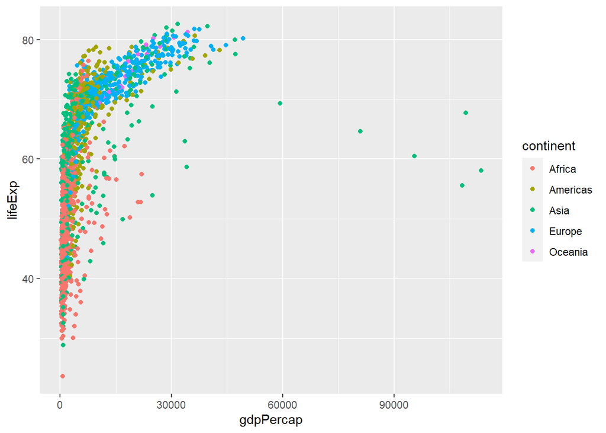

```r
library(ggplot2)
library(gapminder)
ggplot(gapminder, aes(x=gdpPercap, y=lifeExp, col=continent)) +
  geom_point()
```

#### 13. gapminder::gapminder 데이터 셋을 이용하여 기대 수명이 70을 초과하는 데이터에 대해

#### 대륙별 데이터 개수

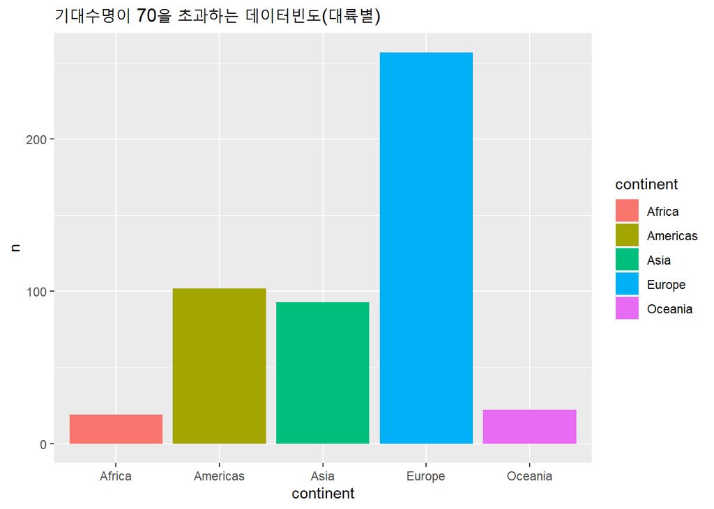

```r
library(ggplot2)
library(gapminder)
library(dplyr)
gapminder %>%
  group_by(continent, lifeExp) %>%
  subset(lifeExp>70) %>%
  summarise(n = n()) %>%
  ggplot(aes(x=continent, y=n, fill=continent)) +
  geom_col() +
  labs(title = '기대수명이 70을 초과하는 데이터빈도(대륙별)')
```

#### 14. gapminder::gapminder 데이터 셋을 이용하여 기대수명이 70을 초과하는 데이터에 대해

#### 대륙별 나라 갯수.

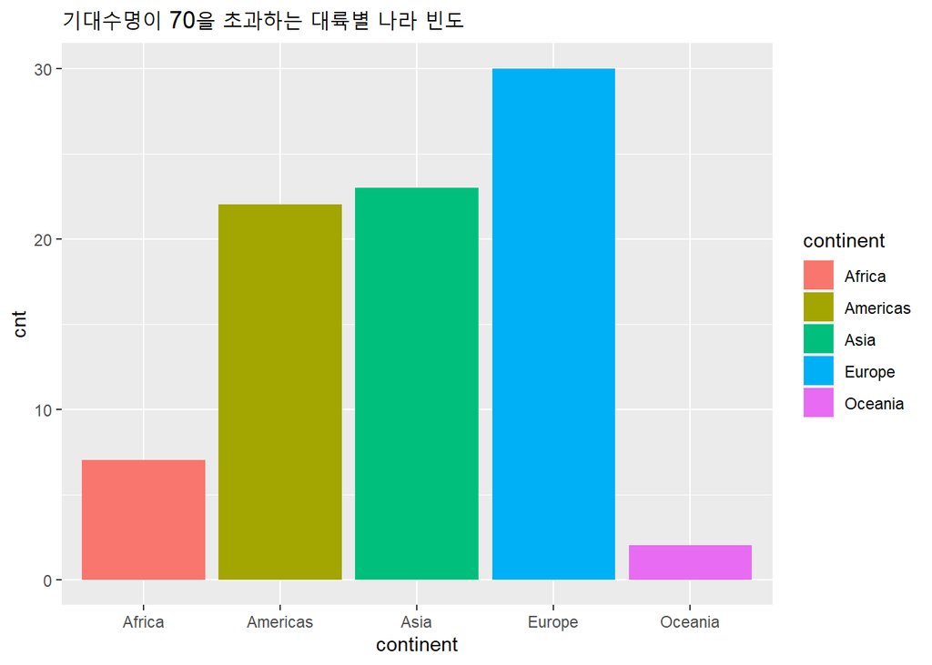

```r
library(ggplot2)
library(gapminder)
library(dplyr)
gapminder %>%
  group_by(continent, country) %>%
  subset(lifeExp>70) %>%
  summarise(n = n()) %>%
  group_by(continent) %>%
  summarise(cnt= n()) %>%
  ggplot(aes(x=continent, y=cnt, fill=continent)) +
  geom_col() +
  labs(title = '기대수명이 70을 초과하는 대륙별 나라 빈도') +
  coord_cartesian(ylim=c(0,30))
```

#### 15. gapminder::gapminder 데이터 셋을 이용하여 대륙별 2007년도(저번에 이부분 뺌) 기대

#### 수명의 사분위수를 시각화

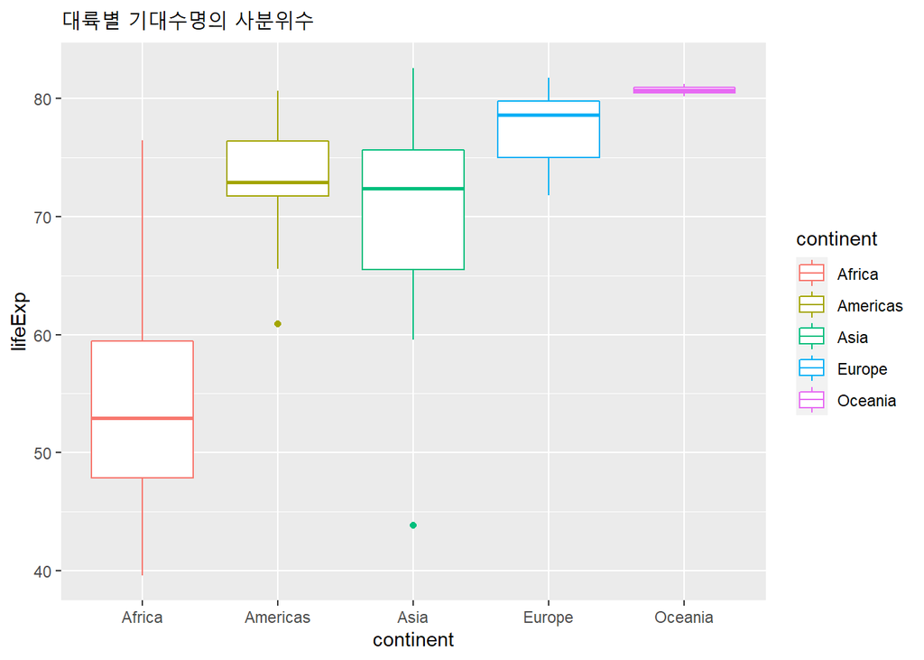

```r
library(ggplot2)
library(gapminder)
library(dplyr)
gapminder %>%
  group_by(continent, lifeExp) %>%
  subset(year==2007) %>%
  ggplot(aes(x=continent, y=lifeExp, col=continent)) +
  geom_boxplot() +
  labs(title = '대륙별 기대수명의 사분위수')
```

#### 16. gapminder::gapminder 데이터 셋을 이용하여 년도별로 gdp와 기대수명과의 관계를 산

#### 점도를 그리고 대륙별 점의 색상을 달리 시각화

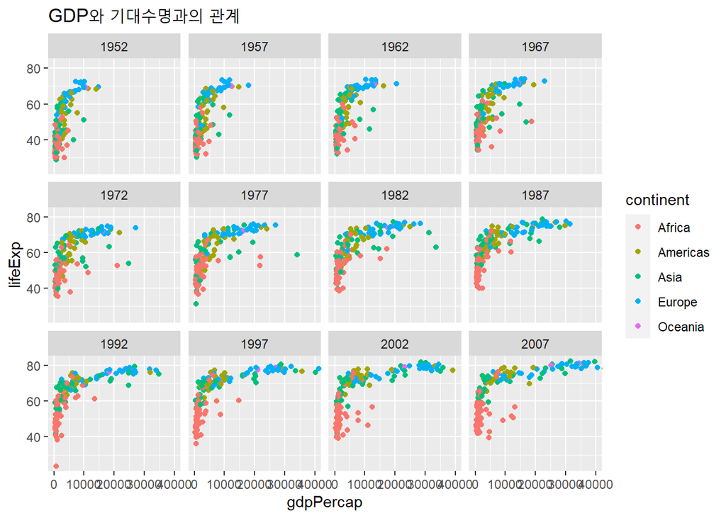

```r
library(ggplot2)
library(gapminder)
ggplot(gapminder, aes(x=gdpPercap, y=lifeExp, col=continent)) +
  geom_point() +
  facet_wrap(~year) +
  labs(title = 'GDP와 기대수명과의 관계')+
  coord_cartesian(xlim=c(0,40000))
```

#### 17. gapminder::gapminder 데이터 셋에서 북한과 한국의 년도별 GDP 변화를 산점도로 시각

#### 화하시오(북한:Korea, Dem. Rep. 한국:Korea, Rep. substr(str, start, end)함수 이용)

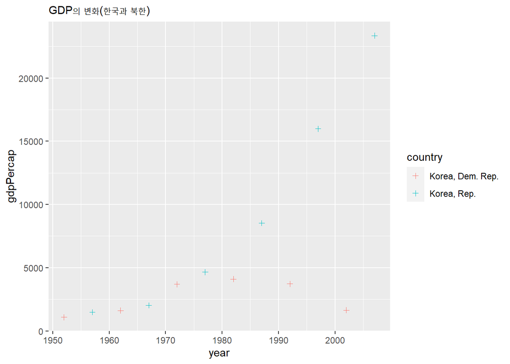

```r
library(ggplot2)
library(gapminder)
gapminder %>%
  group_by(country) %>%
  subset(country==c('Korea, Dem. Rep.', 'Korea, Rep.')) %>%
  ggplot(aes(x=year, y=gdpPercap, col=country)) +
  geom_point(pch=3) +
  labs(subtitle = 'GDP의 변화(한국과 북한)')
```

#### 18. gapminder::gapminder 데이터 셋을 이용하여 한중일 4개국별 GDP 변화를 산점도와 추

#### 세선으로 시각화 하시오.

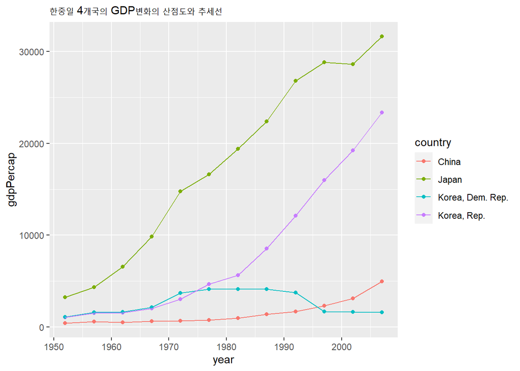

```r
library(ggplot2)
library(gapminder)
country1 <- subset(gapminder, country=='Japan')
country2 <- subset(gapminder, country=='China')
country3 <- subset(gapminder, country=='Korea, Rep.')
country4 <- subset(gapminder, country=='Korea, Dem. Rep.')
all.country <- rbind(country1, country2, country3, country4)
all.country %>%
  group_by(country) %>%
  ggplot(aes(x=year, y=gdpPercap, col=country)) +
  geom_point() +
  geom_line()+
  labs(subtitle = '한중일 4개국의 GDP변화의 산점도와 추세선')
```

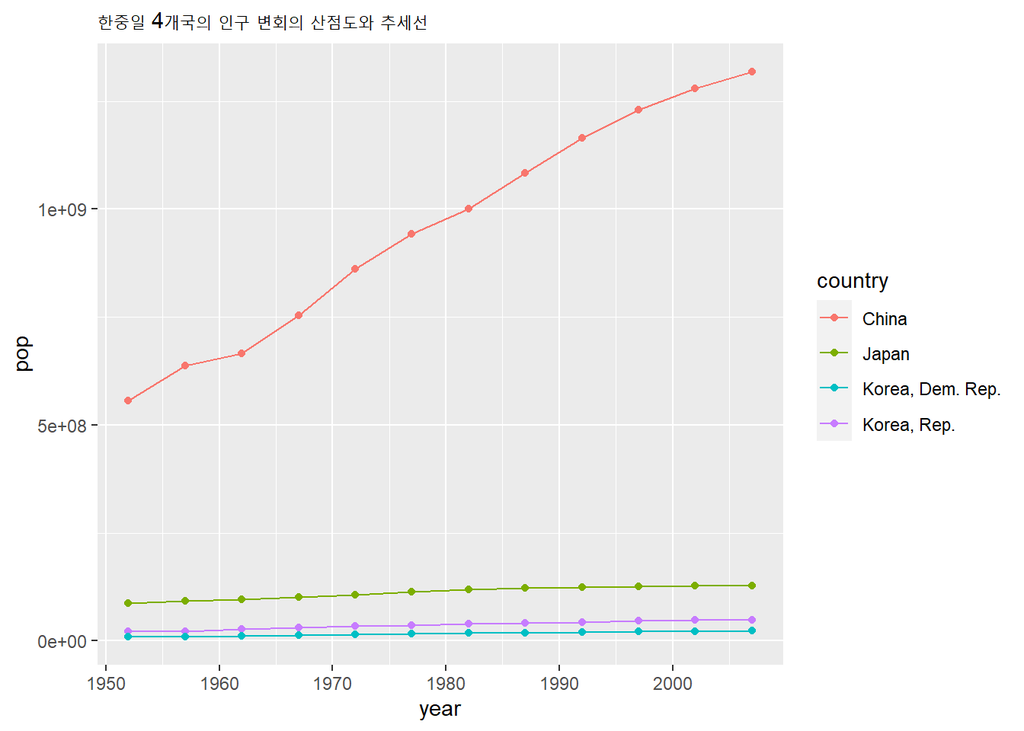

```r
country1 <- subset(gapminder, country=='Japan')
country2 <- subset(gapminder, country=='China')
country3 <- subset(gapminder, country=='Korea, Rep.')
country4 <- subset(gapminder, country=='Korea, Dem. Rep.')
all.country <- rbind(country1, country2, country3, country4)
ggplot(all.country, aes(x=year, y=pop, col=country)) +
  geom_point() +
  geom_line()+
  labs(subtitle = '한중일 4개국의 인구 변회의 산점도와 추세선')
```

```r
library(ggplot2)
ggplot2::economics
```

```
## # A tibble: 574 x 6
##    date         pce    pop psavert uempmed unemploy
##    <date>     <dbl>  <dbl>   <dbl>   <dbl>    <dbl>
##  1 1967-07-01  507. 198712    12.6     4.5     2944
##  2 1967-08-01  510. 198911    12.6     4.7     2945
##  3 1967-09-01  516. 199113    11.9     4.6     2958
##  4 1967-10-01  512. 199311    12.9     4.9     3143
##  5 1967-11-01  517. 199498    12.8     4.7     3066
##  6 1967-12-01  525. 199657    11.8     4.8     3018
##  7 1968-01-01  531. 199808    11.7     5.1     2878
##  8 1968-02-01  534. 199920    12.3     4.5     3001
##  9 1968-03-01  544. 200056    11.7     4.1     2877
## 10 1968-04-01  544  200208    12.3     4.6     2709
## # ... with 564 more rows
```

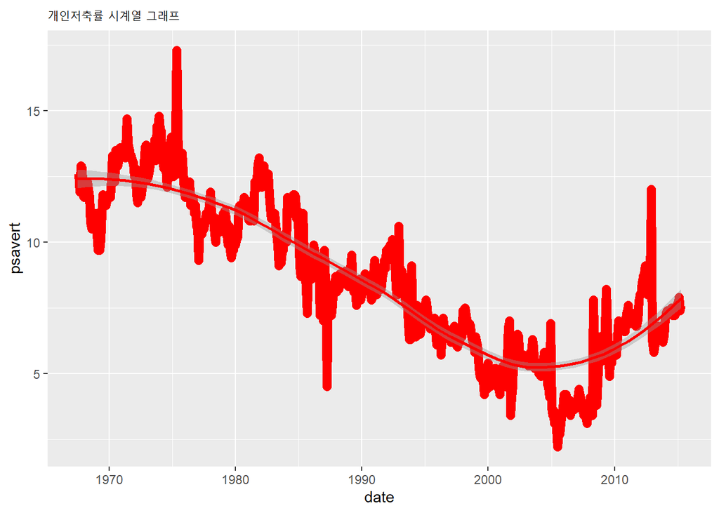

```r
ggplot(economics, aes(x=date, y=psavert)) +
  geom_line(col='red', lwd=3) +
  geom_smooth(col='red') +
  labs(subtitle = '개인저축률 시계열 그래프')
```